# Test a Perceptual Phenomenon

### Analyzing the Stroop Effect

Perform the analysis in the space below. Remember to follow [the instructions](https://docs.google.com/document/d/1-OkpZLjG_kX9J6LIQ5IltsqMzVWjh36QpnP2RYpVdPU/pub?embedded=True) and review the [project rubric](https://review.udacity.com/#!/rubrics/71/view) before submitting. Once you've completed the analysis and write-up, download this file as a PDF or HTML file, upload that PDF/HTML into the workspace here (click on the orange Jupyter icon in the upper left then Upload), then use the Submit Project button at the bottom of this page. This will create a zip file containing both this .ipynb doc and the PDF/HTML doc that will be submitted for your project.

(1) What is the independent variable? What is the dependent variable?

**Answer:**

Independent variable: condition of word(Congruent or Incongruent)

Dependent variable: reaction time

(2) What is an appropriate set of hypotheses for this task? Specify your null and alternative hypotheses, and clearly define any notation used. Justify your choices.

**Answer:**

**Null hypothese**: The population average Congruent reaction time is same as the population average Incongruent reaction time: **$H_{0}$** : **$t_{c}$** - **$t_{i}$**=0

**Alternative hypothese**: The population average Congruent reaction time is different from the population average Incongruent reaction time: **$H_{1}$** : **$t_{c}$** - **$t_{i}$** !=0

**$t_{c}$**: The population average Congruent reaction time(when the color of the ink match the name of the color)

**$t_{i}$**: The population average Incongruent reaction time(when the color of the ink don't match the name of the color)

(3) Report some descriptive statistics regarding this dataset. Include at least one measure of central tendency and at least one measure of variability. The name of the data file is 'stroopdata.csv'.

```python
# Perform the analysis here
import pandas as pd
df=pd.read_csv('stroopdata.csv')
df.head()
```

|  | Congruent | Incongruent |
| --- | --- | --- |
| 0 | 12.079 | 19.278 |
| 1 | 16.791 | 18.741 |
| 2 | 9.564 | 21.214 |
| 3 | 8.630 | 15.687 |
| 4 | 14.669 | 22.803 |

```python
df.shape  #get to know the sample size 24
```

```
(24, 2)
```

Three measures of central tendency:

```python
df.describe() #get mean, and interquartile ranges
```

|  | Congruent | Incongruent |
| --- | --- | --- |
| count | 24.000000 | 24.000000 |
| mean | 14.051125 | 22.015917 |
| std | 3.559358 | 4.797057 |
| min | 8.630000 | 15.687000 |
| 25% | 11.895250 | 18.716750 |
| 50% | 14.356500 | 21.017500 |
| 75% | 16.200750 | 24.051500 |
| max | 22.328000 | 35.255000 |

```python
df.median() #get median
```

```
Congruent      14.3565
Incongruent    21.0175
dtype: float64
```

```python
df.std()  #standard deviation
```

```
Congruent      3.559358
Incongruent    4.797057
dtype: float64
```

```python
df.var()  #variance
```

```
Congruent      12.669029
Incongruent    23.011757
dtype: float64
```

(4) Provide one or two visualizations that show the distribution of the sample data. Write one or two sentences noting what you observe about the plot or plots.

```python
# Build the visualizations here
%matplotlib inline
import seaborn as sns
import matplotlib.pyplot as plt
```

```
Text(0.5,1,'Distribution of Coungruent and Incongruent ')
```

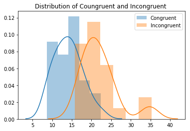

```python
sns.distplot(df['Congruent'],label='Congruent')
sns.distplot(df['Incongruent'],label='Incongruent')

plt.legend()
plt.xlabel('')
#plt.ylabel('')
plt.title('Distribution of Coungruent and Incongruent ')
```

**Answer:**

1. Both of Congruent group and Incongruent group distribution are nearly normal distribution. While the Incongruent is a litte bit right skew.
2. Incongruent group's distribution curve peak is on the right of the congruent group's.

(5) Now, perform the statistical test and report your results. What is your confidence level or Type I error associated with your test? What is your conclusion regarding the hypotheses you set up? Did the results match up with your expectations? **Hint:** Think about what is being measured on each individual, and what statistic best captures how an individual reacts in each environment.

We choose paired sample t-test. Because it is used to determine whether the mean difference between two sets of observations is zero. In our case, the two sets are congruent group and incougurent group. And paired sample t-test, each subject is measured twice. In our case, same subject is measured twice, resulting in pairs of congruent and incougurent situation.

```python
# Perform the statistical test here
import math
from scipy import stats
```

```python
#In this case we use same people in different test(congruent, incongruent)
#so we can use scipy.stats.ttest_rel to caculate the T-test on two related samples of scores, 'Congruent'and'Incongruent'
stats.ttest_rel(df['Congruent'],df['Incongruent'])
```

```
Ttest_relResult(statistic=-8.020706944109957, pvalue=4.103000585711178e-08)
```

**Answer:**

In this test our $\alpha$ level threshold is 0.05, and the p-value is much less than this level. So we can reject the null hypothesis $H_{0}$. And this results match up with our expectations.

**References:**

http://support.minitab.com/en-us/minitab/17/topic-library/basic-statistics-and-graphs/hypothesis-tests/basics/null-and-alternative-hypotheses/

https://docs.scipy.org/doc/scipy-0.14.0/reference/generated/scipy.stats.ttest_rel.html

https://www.statisticssolutions.com/manova-analysis-paired-sample-t-test/

http://seaborn.pydata.org/generated/seaborn.distplot.html

(6) Optional: What do you think is responsible for the effects observed? Can you think of an alternative or similar task that would result in a similar effect? Some research about the problem will be helpful for thinking about these two questions!

**Answer:**

I think this effects might because of the process of the meaning of words has higher priority than processing color in our brain.

Similar task:( Numerical stroop effect ) When people compare digits, their react slowly when the number value and number physical size are different.

**References:** https://en.wikipedia.org/wiki/Numerical_Stroop_effect